# Taller 2: Árboles de decisión

### Integrantes

- Dayana Gonzalez
- Juan Manuel Ramirez

En este taller analizaremos aspectos de árboles de decisión para varios conjuntos de datos. El primero es el [Play tennis dataset](https://www.kaggle.com/datasets/fredericobreno/play-tennis). El segundo es el [Iris dataset](https://archive.ics.uci.edu/ml/datasets/iris). El tercero es el [Pima Indians Diabetes Database](https://www.kaggle.com/datasets/uciml/pima-indians-diabetes-database). El cuarto es [Hitters](https://www.kaggle.com/datasets/floser/hitters).

El taller consiste en realizar todas las tareas señaladas con #TO_DO. Se puede realizar de forma individual o en parejas.

Entregar el cuaderno ejecutado y guardado en formato .ipynb y en formato .html Cargarlo a más tardar el miércoles 22 de febrero en la actividad creada en aulas.

```python
#Importar librerías
import pandas as pd
from sklearn.datasets import load_iris
from sklearn.model_selection import cross_val_score
from sklearn.model_selection import train_test_split
from sklearn.tree import DecisionTreeClassifier, plot_tree, DecisionTreeRegressor
from sklearn import metrics
import matplotlib.pyplot as plt

import math
```

## Calculando el mejor atributo para el Tennis Dataset

En primer lugar, cargar y leer el conjunto de datos Play Tennis, e imprimir todas sus filas (son pocas).

```python
#leer el Play tennis dataset.
#Mostrar todas sus filas.
df = pd.read_csv('play_tennis.csv').dropna()
df.info
```

```
<bound method DataFrame.info of     day   outlook  temp humidity    wind play
0    D1     Sunny   Hot     High    Weak   No
1    D2     Sunny   Hot     High  Strong   No
2    D3  Overcast   Hot     High    Weak  Yes
3    D4      Rain  Mild     High    Weak  Yes
4    D5      Rain  Cool   Normal    Weak  Yes
5    D6      Rain  Cool   Normal  Strong   No
6    D7  Overcast  Cool   Normal  Strong  Yes
7    D8     Sunny  Mild     High    Weak   No
8    D9     Sunny  Cool   Normal    Weak  Yes
9   D10      Rain  Mild   Normal    Weak  Yes
10  D11     Sunny  Mild   Normal  Strong  Yes
11  D12  Overcast  Mild     High  Strong  Yes
12  D13  Overcast   Hot   Normal    Weak  Yes
13  D14      Rain  Mild     High  Strong   No>
```

**TO_DO 1** Clacular la ganancia de información para cada variable: $Gain(S,A)=Ent(S)-\sum_{v\in values(A)}\frac{|S_v|}{|S|}Ent(S_v)$

¿Cuál sería el mejor atributo para comenzar el árbol? Observación: Puede hacer sus cálculos a mano y adjuntar una imagen de los mismos, o programar.

```python
def entropy(df):
    ent = 0
    conteo = df['play'].value_counts()
    for i in range(len(conteo)):
        ent += (conteo[i]/14)*math.log(conteo[i]/14,2)
    return -ent

def gain(df, a):
    g = 0
    conteo = df['play'].value_counts()
    nombres = df[a].unique()
    for i in range(len(nombres)):
        subconteo = df[a].value_counts()
        g += subconteo[i]/14*entropy(df[df[a]==nombres[i]])
    return entropy(df) - g

print('gain in outlook:',gain(df, 'outlook'))
print('gain in temp:',gain(df, 'temp'))
print('gain in humidity:',gain(df, 'humidity'))
print('gain in  wind:',gain(df, 'wind'))
```

```
gain in outlook: 0.1918977830876052
gain in temp: 0.12063715763474936
gain in humidity: 0.04606073001648614
gain in  wind: 0.003558192623777323
```

### Observación:

- Notemos que el atributo con la más alta ganancia representara la raíz del árbol de decisión, así que para el caso de la base de datos anterior el mejor atributo es la variable '*Outlook*'. Por esta razón en el árbol de decisión la variable '*Outlook*' debe ser el atributo que comienza el árbol de decisión como la raíz.

## Árbol de decisión para clasificación del Iris Dataset

Primero definimos el clasificador y lo entrenamos con el conjunto de datos de entrenamiento.

```python
#TO_DO 2 Importar el Iris Dataset usando load_iris de sklearn (ya se importó load_iris). Darle el nombre 'iris'.
# Guardar en X,y las variables de entrada y salida respectivamente, en tipo DataFrame.
# Usar iris.data, iris.target.
iris= load_iris()
x = pd.DataFrame(iris.data, columns =['sepal length (cm)', 'sepal width (cm)', 'petal length (cm)', 'petal width (cm)'] )
x.head()
y = pd.DataFrame(iris.target, columns = ['Tipo'] )
```

```python
#TO_DO 3 Separar en Train y Test set con una proporción de 70%-30%.
X_train,X_test,Y_train,Y_test = train_test_split(x, y, test_size=0.3, random_state=0)
```

```python
#TO_DO 4 Definir un clasificador de árbol de decisión con DecisionTreeClassifier de SKLearn.
#Usar los parámetros random_state=0 y criterion='entropy'
#Entrenarlo


clf = DecisionTreeClassifier(criterion='entropy', random_state=0)
clf.fit(X_train, Y_train)
```

```
DecisionTreeClassifier(criterion='entropy', random_state=0)
```

Medimos la precisión: la proporción entre predicciones correctas y el total de predicciones:

```python
y_pred = clf.predict(X_test)
print("Accuracy:",metrics.accuracy_score(Y_test, y_pred))
```

```
Accuracy: 0.9777777777777777
```

**Plot** Graficamos el árbol obtenido mediante el uso de plot_tree. To_do 5 ¿Qué información identifica en el árbol?

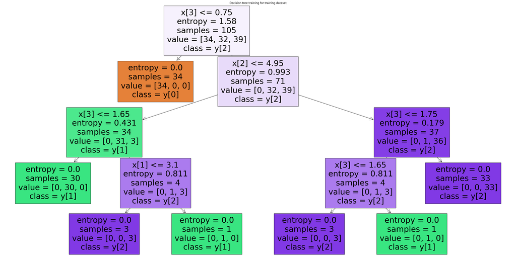

```python
plt.figure(figsize=(40,20))
plot_tree(clf, filled=True, class_names=True)
plt.title("Decision tree training for training dataset")
plt.show()
```

### Observaciones:

**TO_DO 6**: Explore algunos métodos del DecisionTreeClassifier como apply, get_depth, get_n_leaves. Calcúlelos y corrobore su resultado usando el diagrama de árbol.

```python
# Aplicar métodos apply, get_depth, get_n_leaves y entender lo que dicen del árbol.
# Apply :
clf.apply(X_train)
print('Profundidad del arbol:',clf.get_depth())
print('Cantidad de hojas:', clf.get_n_leaves())
```

```
Profundidad del arbol: 4
Cantidad de hojas: 7
```

## Diabetes Dataset

```python
df = pd.read_csv('diabetes.csv').dropna()
df.head()
```

|  | Pregnancies | Glucose | BloodPressure | SkinThickness | Insulin | BMI | DiabetesPedigreeFunction | Age | Outcome |
| --- | --- | --- | --- | --- | --- | --- | --- | --- | --- |
| 0 | 6 | 148 | 72 | 35 | 0 | 33.6 | 0.627 | 50 | 1 |
| 1 | 1 | 85 | 66 | 29 | 0 | 26.6 | 0.351 | 31 | 0 |
| 2 | 8 | 183 | 64 | 0 | 0 | 23.3 | 0.672 | 32 | 1 |
| 3 | 1 | 89 | 66 | 23 | 94 | 28.1 | 0.167 | 21 | 0 |
| 4 | 0 | 137 | 40 | 35 | 168 | 43.1 | 2.288 | 33 | 1 |

A continuación se entrenará un árbol de decisión para el conjunto de datos sobre diabetes.

**TO_DO 7**:

- Entrene un árbol de decisión utilizando el clasificador de SKLearn con un conjunto de entrenamiento del 80% del dataset. Utilice random_state=0 y el criterio de entropía.

**TO_DO 8**:

- Grafique el árbol. ¿Cuál es la precisión de este modelo?

```python
y = df['Outcome']
X = df.drop(columns = ['Outcome'])
```

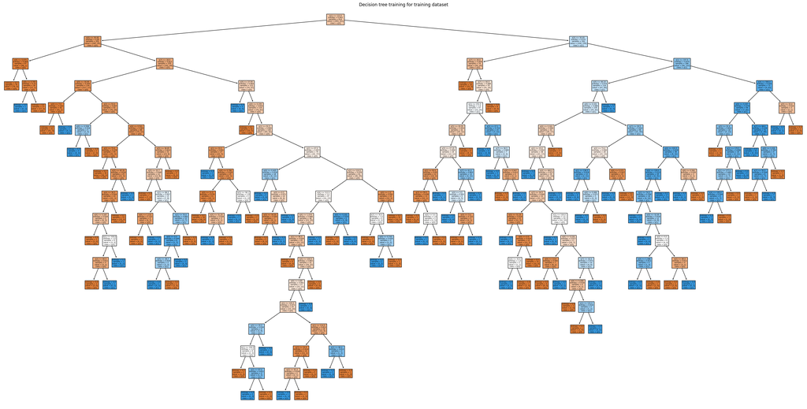

```
Profundidad del arbol: 17
```

```python
X_train,X_test,Y_train,Y_test = train_test_split(X, y, test_size=0.2, random_state=0)
clf = DecisionTreeClassifier(criterion='entropy', random_state=0)
clf.fit(X_train, Y_train)

plt.figure(figsize=(40,20))
plot_tree(clf, filled=True, class_names=True)
plt.title("Decision tree training for training dataset")
plt.show()

print('Profundidad del arbol:',clf.get_depth())
```

```python
y_pred = clf.predict(X_test)
print("Accuracy:",metrics.accuracy_score(Y_test, y_pred))
```

```
Accuracy: 0.7077922077922078
```

## Poda del árbol

Uno de los parámetros del DecisionTreeClassifier es *ccp_alpha*, el cual es un parámetro para la poda del árbol mediante el método *Mínimal cost complexity*. El código siguiente arroja una lista de valores de alpha que resultan efectivos en la poda del árbol.

Entre mayor es el valor de $\alpha$, más se poda el árbol.

```python
path = clf.cost_complexity_pruning_path(X_train, Y_train)
ccp_alphas, impurities = path.ccp_alphas, path.impurities
ccp_alphas
```

```
array([0.        , 0.00325733, 0.00325733, 0.00325733, 0.00354114,
       0.00404381, 0.00434311, 0.00448679, 0.00448679, 0.00448679,
       0.00448679, 0.00448679, 0.00448679, 0.0046164 , 0.00468704,
       0.0048303 , 0.0048303 , 0.00495964, 0.00502633, 0.00522067,
       0.0052852 , 0.0055433 , 0.00560085, 0.00575644, 0.00587889,
       0.00594704, 0.00602679, 0.00604632, 0.00604745, 0.00605368,
       0.00618329, 0.00640444, 0.0064094 , 0.00654328, 0.00655698,
       0.00674546, 0.00684674, 0.00690069, 0.00697625, 0.00702367,
       0.00737675, 0.00768763, 0.00785562, 0.00787552, 0.00812098,
       0.00818056, 0.0086791 , 0.00869433, 0.00897357, 0.00914306,
       0.00924392, 0.00994398, 0.01118351, 0.01151191, 0.0120048 ,
       0.01282652, 0.02102938, 0.02130657, 0.0278788 , 0.03683399,
       0.04500223, 0.13153424])
```

**TO_DO 9:** Usando el arreglo de valores de *ccp_alpha* arrojados en la celda anterior, crear un loop que entrene un árbol para cada parámetro de ccp_alpha e imprima su precisión. ¿Cuál es el valor de ccp_alpha optimo?

```python
besto = 0
besto_alfa = 0
for i in range(len(ccp_alphas)):
    clf = DecisionTreeClassifier(criterion='entropy', random_state=0, ccp_alpha = ccp_alphas[i] )
    clf.fit(X_train, Y_train)
    y_pred = clf.predict(X_test)
    prec = metrics.accuracy_score(Y_test, y_pred)
    print("Para alfa", ccp_alphas[i], "Accuracy:", prec)
    if prec > besto:
        besto = prec
        besto_alfa = ccp_alphas[i]

print("Besto friendo es:", besto, "con alfa:", besto_alfa)
```

```
Para alfa 0.0 Accuracy: 0.7077922077922078
Para alfa 0.003257328990228013 Accuracy: 0.7207792207792207
Para alfa 0.003257328990228013 Accuracy: 0.7207792207792207
Para alfa 0.003257328990228013 Accuracy: 0.7207792207792207
Para alfa 0.003541136437782387 Accuracy: 0.7207792207792207
Para alfa 0.004043812869416617 Accuracy: 0.7207792207792207
Para alfa 0.004343105320304018 Accuracy: 0.7142857142857143
Para alfa 0.004486787462806952 Accuracy: 0.7142857142857143
Para alfa 0.004486787462806952 Accuracy: 0.7142857142857143
Para alfa 0.004486787462806952 Accuracy: 0.7142857142857143
Para alfa 0.004486787462806952 Accuracy: 0.7142857142857143
Para alfa 0.004486787462806952 Accuracy: 0.7142857142857143
Para alfa 0.004486787462806952 Accuracy: 0.7142857142857143
Para alfa 0.0046163955311671785 Accuracy: 0.7142857142857143
Para alfa 0.0046870367403543675 Accuracy: 0.7207792207792207
Para alfa 0.0048302967486052156 Accuracy: 0.7207792207792207
Para alfa 0.004830296748605221 Accuracy: 0.7207792207792207
Para alfa 0.004959635958376633 Accuracy: 0.7207792207792207
Para alfa 0.0050263295230949905 Accuracy: 0.7272727272727273
Para alfa 0.005220674778766189 Accuracy: 0.7142857142857143
Para alfa 0.005285199507877087 Accuracy: 0.7142857142857143
Para alfa 0.005543302733648896 Accuracy: 0.7142857142857143
Para alfa 0.005600847360405197 Accuracy: 0.7207792207792207
Para alfa 0.005756438074987935 Accuracy: 0.7207792207792207
Para alfa 0.005878893280841712 Accuracy: 0.7207792207792207
Para alfa 0.00594704308534728 Accuracy: 0.7142857142857143
Para alfa 0.0060267930677611395 Accuracy: 0.7142857142857143
Para alfa 0.006046320073832434 Accuracy: 0.7142857142857143
Para alfa 0.00604744634202081 Accuracy: 0.7272727272727273
Para alfa 0.006053678869362694 Accuracy: 0.7272727272727273
Para alfa 0.0061832869377229215 Accuracy: 0.7207792207792207
Para alfa 0.006404437249300772 Accuracy: 0.7207792207792207
Para alfa 0.006409400892539968 Accuracy: 0.7207792207792207
Para alfa 0.006543278194560575 Accuracy: 0.7207792207792207
Para alfa 0.006556977630964112 Accuracy: 0.7207792207792207
Para alfa 0.006745455130417414 Accuracy: 0.7207792207792207
Para alfa 0.006846737872456488 Accuracy: 0.7402597402597403
Para alfa 0.006900690134768748 Accuracy: 0.7402597402597403
Para alfa 0.006976252280378801 Accuracy: 0.7402597402597403
Para alfa 0.0070236661112516655 Accuracy: 0.7402597402597403
```

[output cut: 8 more lines]

```
Para alfa 0.008973574925613905 Accuracy: 0.7402597402597403
Para alfa 0.009143064340913026 Accuracy: 0.7337662337662337
Para alfa 0.009243915459318366 Accuracy: 0.7532467532467533
Para alfa 0.009943975646005479 Accuracy: 0.7532467532467533
Para alfa 0.011183514974848457 Accuracy: 0.7532467532467533
Para alfa 0.011511908800140969 Accuracy: 0.7792207792207793
Para alfa 0.012004800622679931 Accuracy: 0.7727272727272727
Para alfa 0.012826517710630762 Accuracy: 0.7597402597402597
Para alfa 0.021029382648115505 Accuracy: 0.7597402597402597
Para alfa 0.021306568283758043 Accuracy: 0.7597402597402597
Para alfa 0.02787879900735951 Accuracy: 0.7597402597402597
Para alfa 0.036833986646986505 Accuracy: 0.7207792207792207
Para alfa 0.04500222816035104 Accuracy: 0.7207792207792207
Para alfa 0.1315342361726266 Accuracy: 0.6948051948051948
Besto friendo es: 0.7792207792207793 con alfa: 0.011511908800140969
```

**TO_DO 10:** Entrenar un clasificador con el ccp_alpha óptimo. Graficarlo y compararlo con el árbol inicial.

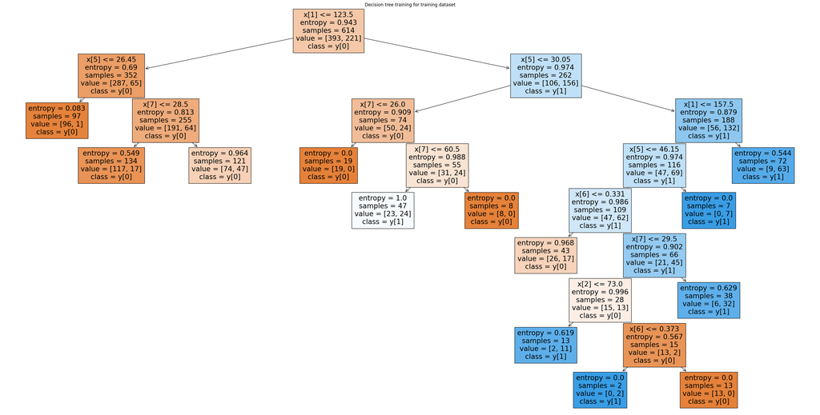

```
Profundidad del arbol: 8
```

```python
clf = DecisionTreeClassifier(criterion='entropy', random_state=0, ccp_alpha = besto_alfa)
clf.fit(X_train, Y_train)

plt.figure(figsize=(40,20))
plot_tree(clf, filled=True, class_names=True)
plt.title("Decision tree training for training dataset")
plt.show()

print('Profundidad del arbol:',clf.get_depth())
```

```python
y_pred = clf.predict(X_test)
print("Accuracy:",metrics.accuracy_score(Y_test, y_pred))
```

```
Accuracy: 0.7792207792207793
```

### Observación:

- Comparando ambos árboles, podemos darnos cuenta que disminuyeron la cantidad de hojas y la profundidad del árbol, ya que el árbol inicial contaba con 17 de profundidad en cambio el árbol podado cuenta con 8. Además, el árbol podado cuenta con el Alpha óptimo para realizar el podado del árbol. Además, mediante la precisión del modelo podemos darnos cuenta de que el árbol de decisión podado tubo una mayor precisión en la clasificación que el anterior.

## Árbol de regresión

Para éste ejercicio usamos el dataset de Hitters, cuya variable objetivo es el salario, el cual no es una variable categórica. Para esto necesitamos un árbol de regresión. A saber, DecisionTreeRegressor.

Primero leemos el dataset, y consideramos como entrada X únicamente dos de sus variables: Years, Hits. Tomamos como variable objetivo el salario.

```python
df = pd.read_csv('Hitters.csv').dropna()
df.info()
```

```
<class 'pandas.core.frame.DataFrame'>
Int64Index: 263 entries, 1 to 321
Data columns (total 20 columns):
 #   Column     Non-Null Count  Dtype
---  ------     --------------  -----
 0   AtBat      263 non-null    int64
 1   Hits       263 non-null    int64
 2   HmRun      263 non-null    int64
 3   Runs       263 non-null    int64
 4   RBI        263 non-null    int64
 5   Walks      263 non-null    int64
 6   Years      263 non-null    int64
 7   CAtBat     263 non-null    int64
 8   CHits      263 non-null    int64
 9   CHmRun     263 non-null    int64
 10  CRuns      263 non-null    int64
 11  CRBI       263 non-null    int64
 12  CWalks     263 non-null    int64
 13  League     263 non-null    object
 14  Division   263 non-null    object
 15  PutOuts    263 non-null    int64
 16  Assists    263 non-null    int64
 17  Errors     263 non-null    int64
 18  Salary     263 non-null    float64
 19  NewLeague  263 non-null    object
dtypes: float64(1), int64(16), object(3)
memory usage: 43.1+ KB
```

```python
X = df[['Years', 'Hits']] # Tomamos sólo dos de las columnas
y = df.Salary
```

**TO_DO 11** Entrenar un árbol de regresión en X,y con el parámetro max_leaf_nodes=3; usar el método score (coeficiente de determinación)para medir su desempeño, y graficarlo.

```python
## código aquí

dec = DecisionTreeRegressor(max_leaf_nodes = 3 )
dec.fit(X, y)

dec.score(X,y)
```

```
0.43665573627391885
```

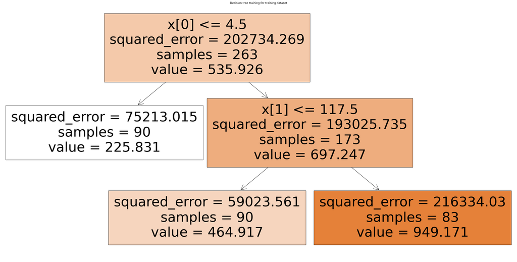

```python
## Graficar el árbol
plt.figure(figsize=(40,20))
plot_tree(dec, filled=True, class_names=True)
plt.title("Decision tree training for training dataset")
plt.show()
```

**TO_DO 12:** ¿En cuántas regiones $R_i$ separó el espacio de las dos variables de entrada el árbol anterior? Descríbalas.

## Respuesta:

El árbol de regresión cuenta con 3 regiones. Inicialmente se tiene una división basada en la cantidad de años que el jugador ha pertenecido a las ligas mayores siendo 4.5 el nivel determinante que diferencia el grupo de 90 bateadores de menores ingresos con 225.831 en promedio del resto de jugadores con 697.247 en promedio. Este segundo grupo se bifurca nuevamente según la cantidad de aciertos realizados siendo 117.5 aciertos el nivel diferenciador. El resultado de esta segunda separación es un grupo de 90 jugadores de ingresos medios con media 464.917 y el grupo de 83 jugadores con mayores ingresos de 949.171